# Covid-19 Mortality: An Analysis of Demographic Data

```r
covid_us <- covid_us %>%
  mutate(fips = FIPS)

pm_mean = county_pm %>%
  group_by(fips) %>%
  summarise(pm25 = mean(pm25))
```

```r
covid_us <- covid_us %>%
  group_by(fips) %>%
  mutate(mortality = (1+Deaths)/Confirmed) %>%
  filter(mortality<1 & !is.na(mortality))
```

```r
full <- inner_join(covid_us, census_ave, by = "fips")
full <- full %>%
  mutate(poverty = 100*poverty, medianhouseholdincome = medianhouseholdincome/1000, medianhousevalue = medianhousevalue/1000, pct_blk = pct_blk*100, pct_asian = pct_asian*100, pct_native = pct_native*100, hispanic = hispanic*100, pct_white = pct_white*100, education = education*100, pct_owner_occ = pct_owner_occ*100)
```

## Exploratory Data Analysis

## Mortality Rates & Race

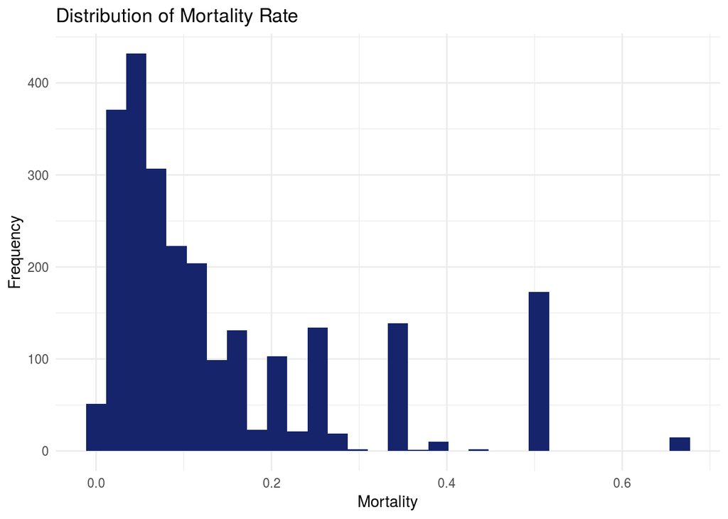

```r
ggplot(data = full, mapping = aes(x = mortality))+
  geom_histogram(fill = "#15246b" )+
  labs(title = "Distribution of Mortality Rate", x = "Mortality", y = "Frequency") +
  theme_minimal()
```

This is our response variable, mortality. The distribution is unimodal and right-skewed with a few outliers.

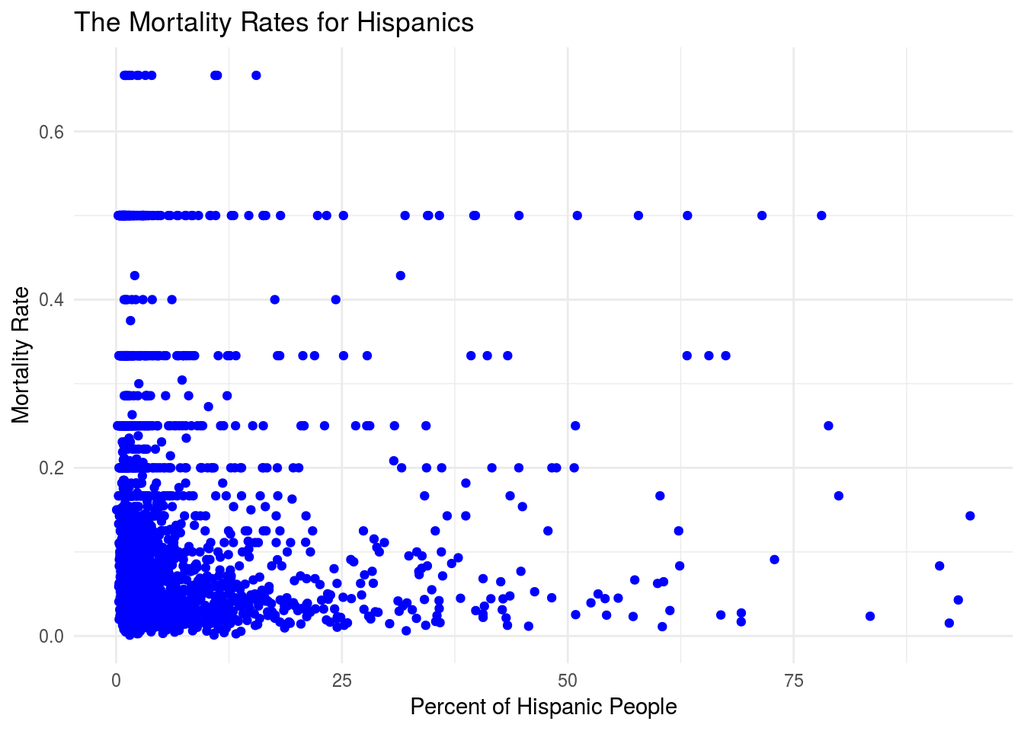

```r
ggplot(data = full, mapping = aes(x = hispanic, y = mortality)) +
  geom_point(color = "blue")+
  labs(title = "The Mortality Rates for Hispanics",
       x = "Percent of Hispanic People", y = "Mortality Rate") +
theme_minimal()
```

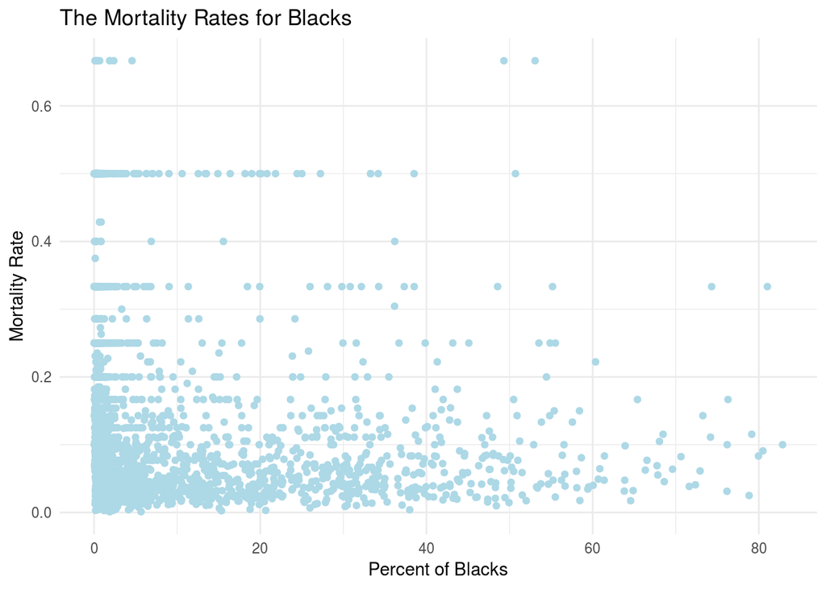

```r
ggplot(data = full, mapping = aes(x = pct_blk, y = mortality)) +
  geom_point(color = "lightblue")+
  labs(title = "The Mortality Rates for Blacks",
       x = "Percent of Blacks", y = "Mortality Rate") +
  theme_minimal()
```

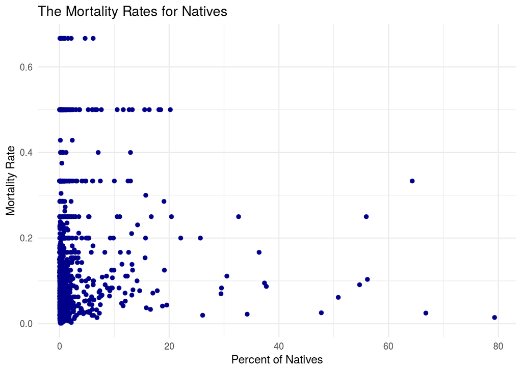

```r
ggplot(data = full, mapping = aes(x = pct_native, y = mortality) )+
  geom_point(color = "darkblue")+
  labs(title = "The Mortality Rates for Natives",
       x = "Percent of Natives", y = "Mortality Rate") +
  theme_minimal()
```

There is no apparent relationship between racial group and mortality rate.

## Mortality, Home-ownership, & Income

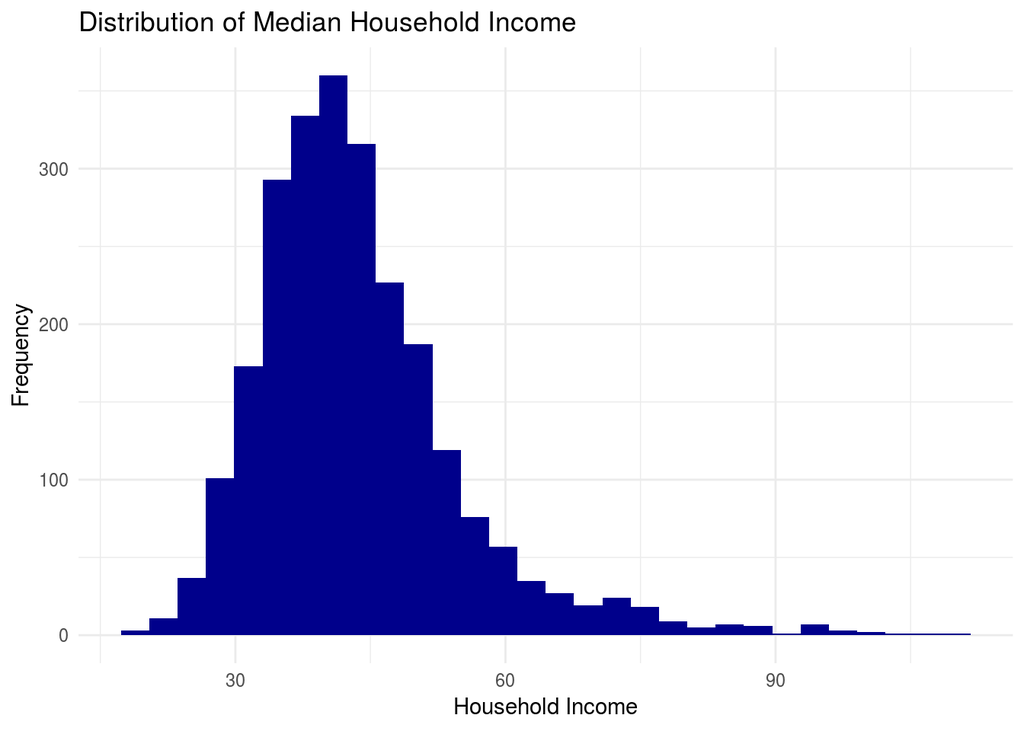

```r
ggplot(data = full, mapping = aes(x = medianhouseholdincome))+
  geom_histogram(fill = "darkblue")+
  labs(title = "Distribution of Median Household Income",
       x = "Household Income", y = "Frequency") +
  theme_minimal()
```

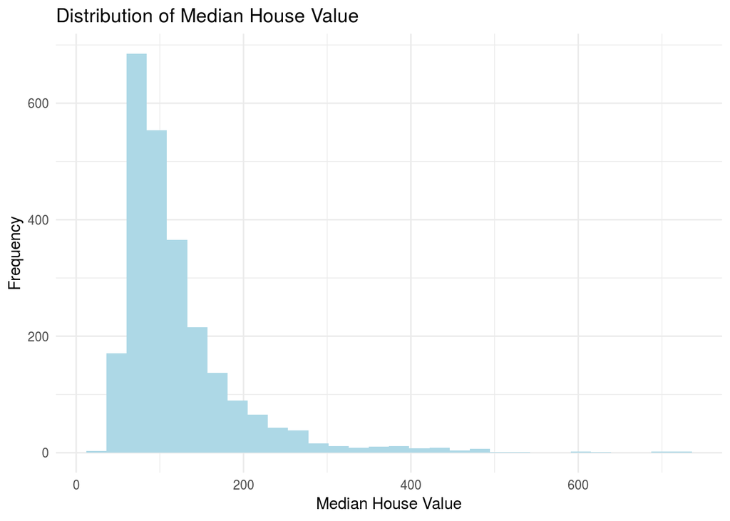

```r
ggplot(data = full, mapping = aes(x = medianhousevalue)) +
  geom_histogram(fill = "lightblue") +
  labs(title = "Distribution of Median House Value",
       x = "Median House Value", y = "Frequency") +
  theme_minimal()
```

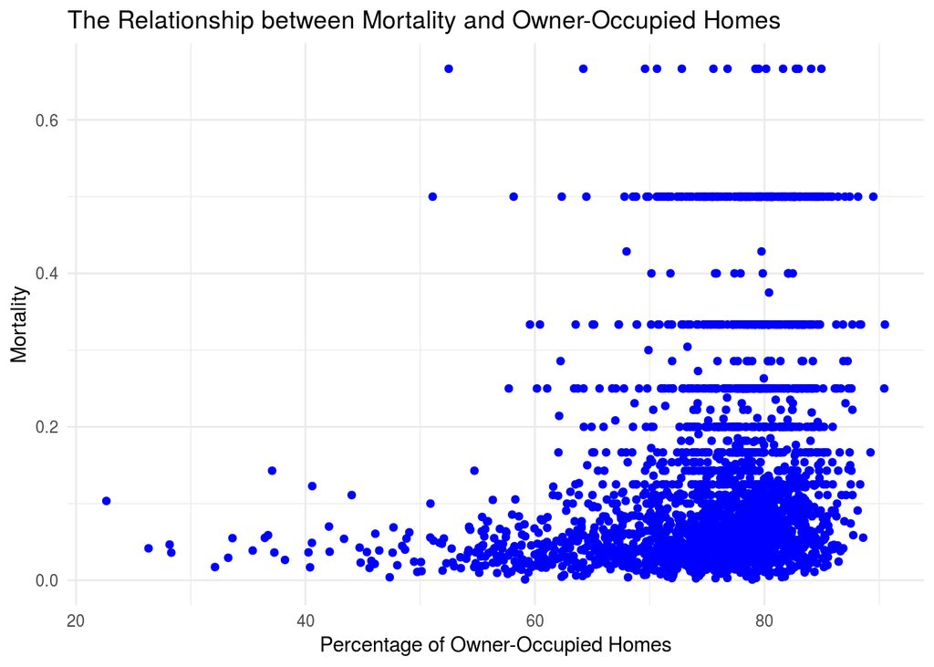

```r
ggplot(data = full, mapping = aes(x = pct_owner_occ, y = mortality)) +
  geom_point(color = "blue")+
  labs(title = "The Relationship between Mortality and Owner-Occupied Homes",
       x = "Percentage of Owner-Occupied Homes", y = "Mortality") +
  theme_minimal()
```

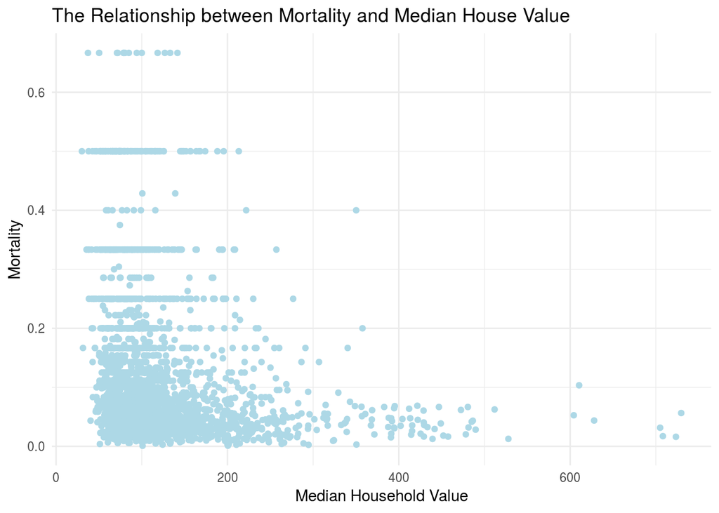

```r
ggplot(data = full, mapping = aes(x = medianhousevalue, y = mortality)) +
  geom_point(color = "lightblue")+
  labs(title = "The Relationship between Mortality and Median House Value",
         x = "Median Household Value", y = "Mortality") +
  theme_minimal()
```

[figure not shown]

```r
ggplot(data = full, mapping = aes(x = medianhouseholdincome, y = mortality)) +
  geom_point(color = "darkblue")+
  labs(title = "The Mortality Rates for Blacks",
        x = "Median Household Income", y = "Mortality") +
  theme_minimal()
```

## Poverty & Race

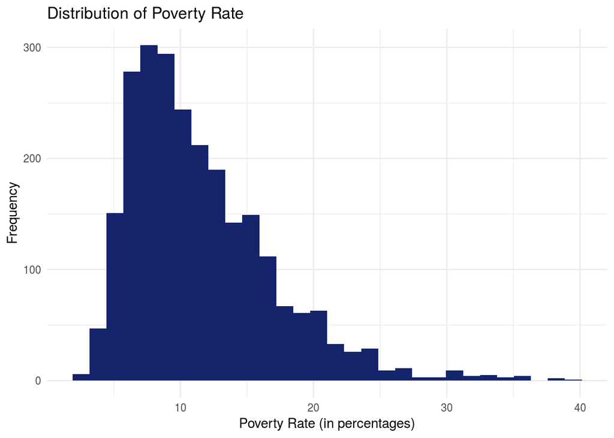

```r
ggplot(data = full, mapping = aes(x = poverty))+
  geom_histogram(fill = "#15246b") +
  labs(title = "Distribution of Poverty Rate",
       x = "Poverty Rate (in percentages)", y = "Frequency") +
  theme_minimal()
```

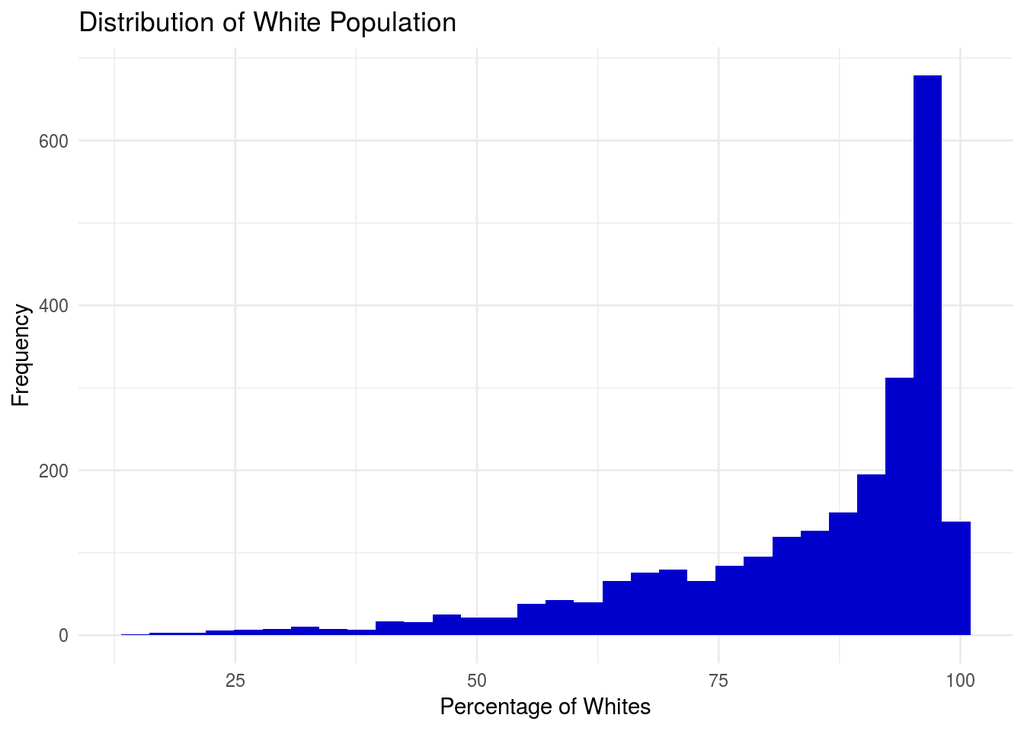

```r
ggplot(data = full, mapping = aes(x = pct_white))+
  geom_histogram(fill = "mediumblue") +
  labs(title = "Distribution of White Population",
       x = "Percentage of Whites", y = "Frequency") +
  theme_minimal()
```

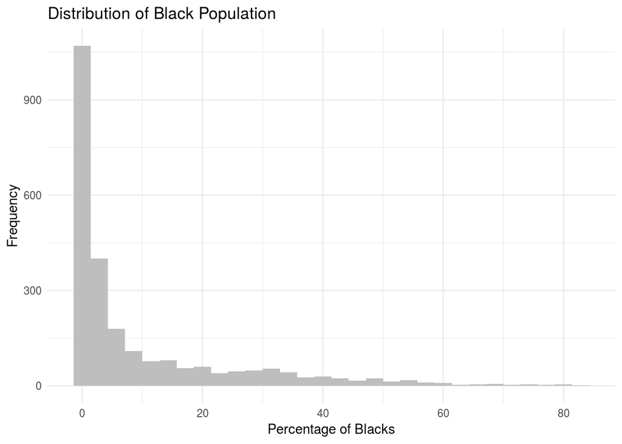

```r
ggplot(data = full, mapping = aes(x = pct_blk))+
  geom_histogram(fill="gray") +
  labs(title = "Distribution of Black Population",
       x = "Percentage of Blacks", y = "Frequency") +
  theme_minimal()
```

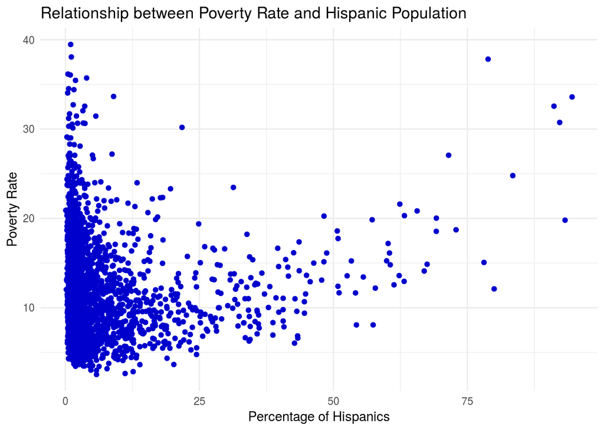

```r
ggplot(data = full, mapping = aes(x = hispanic, y = poverty))+
  geom_point(color = "mediumblue")+
  labs(title = "Relationship between Poverty Rate and Hispanic Population",
       x = "Percentage of Hispanics", y = "Poverty Rate") +
  theme_minimal()
```

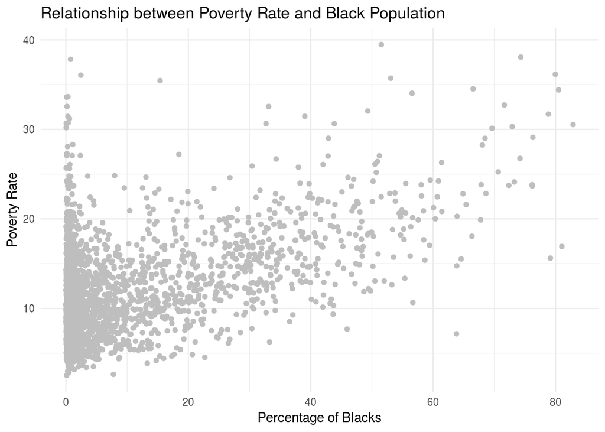

```r
ggplot(data = full, mapping = aes(x = pct_blk, y = poverty))+
  geom_point(color = "gray")+
  labs(title = "Relationship between Poverty Rate and Black Population",
       x = "Percentage of Blacks", y = "Poverty Rate") +
  theme_minimal()
```

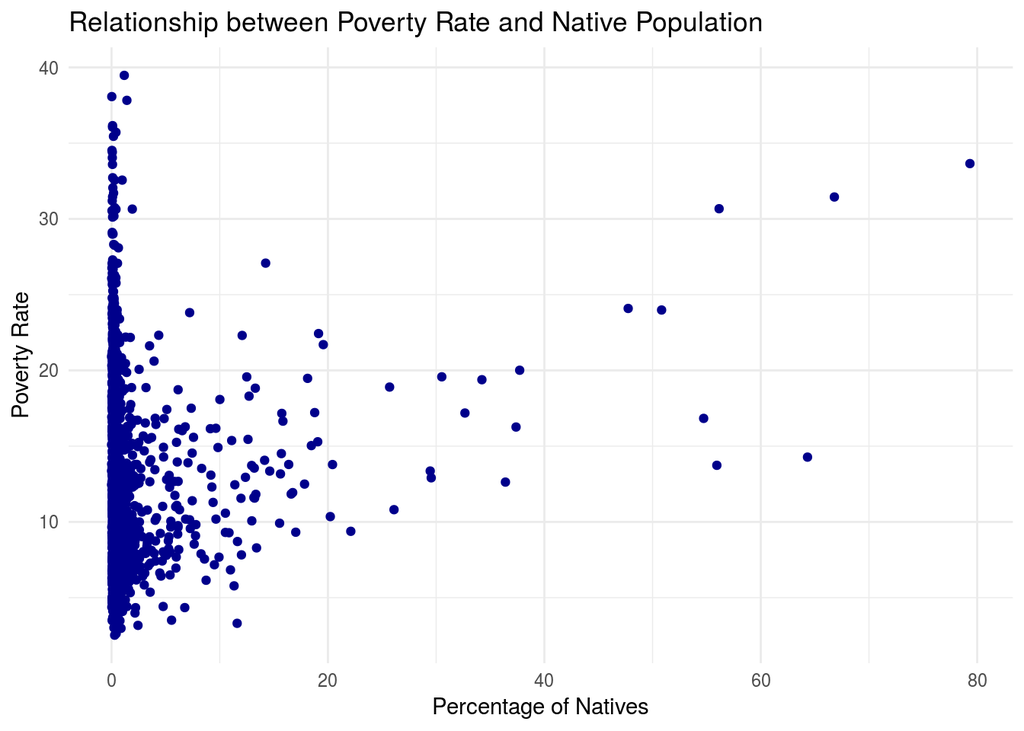

```r
ggplot(data = full, mapping = aes(x = pct_native, y = poverty))+
  geom_point(color = "darkblue")+
  labs(title = "Relationship between Poverty Rate and Native Population",
       x = "Percentage of Natives", y = "Poverty Rate") +
  theme_minimal()
```

## Mortality & Poverty

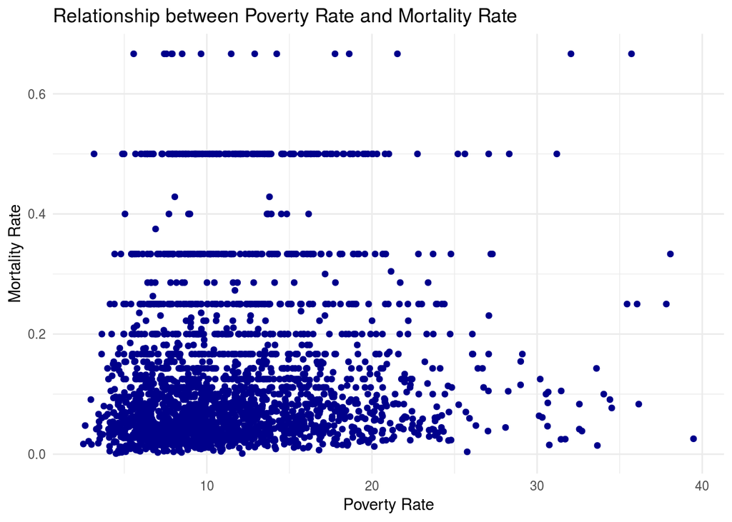

```r
ggplot(data = full, mapping = aes(x = poverty, y = mortality))+
  geom_point(color = "darkblue")+
  labs(title = "Relationship between Poverty Rate and Mortality Rate",
       x = "Poverty Rate", y = "Mortality Rate") +
  theme_minimal()
```

## Regression model

```r
mod <- betareg(mortality ~ poverty + medianhouseholdincome + medianhousevalue + pct_asian + pct_white + pct_native + education + popdensity + pct_owner_occ + pct_white*education + poverty*pct_blk +poverty*pct_native, data = full)
tidy(mod) %>%
  kable(format = "markdown", digits = 6)
```

| component | term | estimate | std.error | statistic | p.value |
| --- | --- | --- | --- | --- | --- |
| mean | (Intercept) | -4.344063 | 0.676368 | -6.422636 | 0.000000 |
| mean | poverty | 0.031076 | 0.005920 | 5.248975 | 0.000000 |
| mean | medianhouseholdincome | -0.024998 | 0.002711 | -9.221812 | 0.000000 |
| mean | medianhousevalue | -0.001367 | 0.000403 | -3.392109 | 0.000694 |
| mean | pct_asian | 0.039633 | 0.013848 | 2.861947 | 0.004210 |
| mean | pct_white | 0.021163 | 0.007165 | 2.953616 | 0.003141 |
| mean | pct_native | 0.051207 | 0.012087 | 4.236574 | 0.000023 |
| mean | education | 0.019743 | 0.012664 | 1.558975 | 0.119002 |
| mean | popdensity | 0.000025 | 0.000014 | 1.853026 | 0.063879 |
| mean | pct_owner_occ | 0.025532 | 0.002846 | 8.972491 | 0.000000 |
| mean | pct_blk | -0.004938 | 0.006016 | -0.820754 | 0.411786 |
| mean | pct_white:education | -0.000351 | 0.000141 | -2.492254 | 0.012694 |
| mean | poverty:pct_blk | -0.000227 | 0.000221 | -1.026780 | 0.304524 |
| mean | poverty:pct_native | -0.002515 | 0.000525 | -4.789308 | 0.000002 |
| precision | (phi) | 9.234437 | 0.269750 | 34.233361 | 0.000000 |

The most significant predictor variables are poverty, medianhouseholdincome, medianhousevalue, pct_native, and pct_owner_occ.

For every 1 percent increase in the poverty rate, we expect the odds of a confirmed patient dying to increase by a multiplicative factor of exp(0.031076) = 1.0316, holding all else constant.

For every 1 percent increase in pct_native, we expect the odds of a confirmed patient dying to increase by a multiplicative factor of exp(0.051207) = 1.0525, holding all else constant.

For every additional $1000 in medianhouseholdincome, we expect the odds of a confirmed patient dying to change by a multiplicative factor of exp(-0.024998) = 0.975, holding all else constant.

For every additional $1000 in medianhousevalue, we expect the odds of a confirmed patient dying to change by a multiplicative factor of exp(-0.001367) = 0.9986, holding all else constant.